# Custo de Capital

Ross et al. (2022), capítulo 14

Marcelo S. Perlin

EA-UFRGS

29/04/2026

# Introdução ao custo de capital

## Custo do Capital

> Custo do Capital (ou taxa de desconto): Remuneração mínima para os projetos da empresa
- Das aulas anteriores:
  - Projeto é analisado olhando para o VPL do mesmo, dada arbitrariamente uma taxa de custo de capital (geralmente e erroneamente uma taxa livre de risco)
  - A incerteza pode ser analisada via cenários e análise de sensibilidade
- O custo de capital da empresa vai ser formado por:
  - Custo do capital próprio
  - Custo do capital de terceiro

## Pergunta #1

> Você emprestou 1000 R$ para seu amigo, cobrando 15% de juros anuais. Seu amigo irá utilizar esse capital para investir em um projeto de 1000 R$. Qual o custo de capital (mínima remuneração) que **seu amigo** deve utilizar para calcular o VPL do projeto?
1. Retorno anual da poupança
2. Retorno anual do CDB pós fixado
3. 15%
4. Retorno anual médio do Ibovespa
5. Nenhuma das anteriores

## Pergunta #2

> O mesmo amigo anterior pegou emprestado 1000 R$ contigo e 500 R$ com outra pessoa. Você e essa outra pessoa querem 10% e 20% de juros, respectivamente. Qual o custo de capital para o seu amigo devedor?
1. Retorno anual da poupança
2. 10%
3. 20%
4. 13,33%
5. Retorno anual médio do Ibovespa

## Pergunta #3

> O mesmo amigo anterior pegou emprestado 500 R$ contigo e 500 R$ com outra pessoa. Enquanto você ainda quer os 10% de juros, essa outra pessoa pediu 50% dos lucros obtidos nos projetos. Qual o custo de capital para o seu amigo devedor?
1. Retorno anual da poupança
2. 10%
3. 15%
4. Retorno anual médio do Ibovespa
5. Impossível de dizer sem maiores informações

# Como Calcular o Custo de Capital de uma Empresa

## Fatores determinantes do custo de capital de uma empresa

- Taxa livre de risco
- Risco do negócio (maior o risco, maior o custo do capital de terceiros e próprio)
- Estrutura do capital da empresa
  - Proporção de Capital Próprio
    - Capital que dá direito sobre os fluxos de caixa dos projetos da empresa
  - Proporção de Capital de terceiros
    - Capital que remunera de forma fixa o detentor das dívidas da empresa

## Custo total do capital da empresa

- Custo do capital próprio
  - Abordagens:
    - Modelo de crescimento de dividendos (Gordon)
    - Linha do mercado de títulos (CAPM)
- Custo do capital de terceiro
  - Abordagem: cálculo do YTM (TIR) da dívida

# Cálculo do custo do capital próprio

## Modelo de crescimento de dividendos (Gordon and Shapiro 1956)

- Premissas:
  - Tempo infinito (ação nunca é vendida)
  - Dividendos crescentes de forma constante

$$r = \frac{DIV_0(1+g)}{P_0}+g$$
Onde:

$DIV_0$ - Dividendo pago na data $t=0$

$g$ - taxa de crescimento dos dividendos

$P_0$ - preço atual da ação

## Exemplo

> As ações de uma empresa possuem um preço hoje de R$ 120, um dividendo hoje de R$ 12 e uma taxa de crescimento de dividendos de 2,50%. Qual o custo do capital próprio da empresa?

$$r = \frac{DIV_0(1+g)}{P_0}+g$$
$$r = \frac{12(1+0.025)}{120}+0.025 = 0.1275$$

O custo de capital próprio é de 12,75%

## Cálculo de g

> Como calcular a taxa de crescimento dos dividendos (g) ?

| Ano | Dividendo | Variação % |
| --- | --- | --- |
| 2026 | R$1.07 | NA |
| 2027 | R$1.23 | 15.06% |
| 2028 | R$1.50 | 21.94% |
| 2029 | R$1.69 | 12.89% |
| 2030 | R$2.01 | 18.91% |

O valor de $g$ é a média da variação percentual do dividendos entre os anos: 17,20%

## Vantagens e desvantagens

- Vantagens
  - Simplicidade
- Desvantagens
  - Implementável apenas para empresas que pagam dividendos
  - Premissa de dividendo crescente
  - Efeito do risco sobre custo do capital é pouco explícito

## Abordagem da SML (LMT)

> Baseado no modelo CAPM, projetando um equilíbrio entre risco e retorno

$$r = R_f + \beta (R_M - R_f)$$

Onde:

$r$ - custo do capital próprio da empresa

$R_f$ - taxa livre de risco da economia

$\beta$ - coeficiente beta (risco sistêmico da empresa)

$R_M$ - Retorno esperado da carteira de mercado (Ibovespa)

# Alguns custos de capitais atuais

## Custo de capital de empresas da B3

Custo de Capital de várias empresas

Dados atualizados em 2026-04-29

| ticker | beta | R_f | R_M | R |
| --- | --- | --- | --- | --- |
| SAPR3.SA | −0.11 | 10.00% | 13.22% | 9.66% |
| PETR3.SA | 1.18 | 10.00% | 13.22% | 13.80% |
| ITSA3.SA | 1.21 | 10.00% | 13.22% | 13.89% |
| EGIE3.SA | 1.53 | 10.00% | 13.22% | 14.92% |
| GRND3.SA | 1.99 | 10.00% | 13.22% | 16.39% |

## Vantagens e desvantagens

- Vantagens
  - Ajuste por risco
  - Fácil implementação, desde que a empresa é listada em bolsa
- Desvantagens
  - Empresa tem que estar listada no mercado acionário

# Custo do capital de terceiros

## Cálculo do custo de capital de terceiros

> Custo do capital de terceiros = retorno exigido pelos credores da empresa
- Taxa a ser paga na obtenção de crédito
  - Facilmente obtido ao analisar as dívidas correntes da empresa, em relação ao total pago em juros
- No caso de múltiplas dívidas, com taxas diferentes, uma média ponderada pode ser utilizada

## Exemplo

> Exemplo: uma empresa emite um título de renda fixa com prazo de 10 anos, valor de face igual a R$ 100, cupom de 7,00% e o preço hoje é de R$ 96. Qual o custo do capital de terceiros?

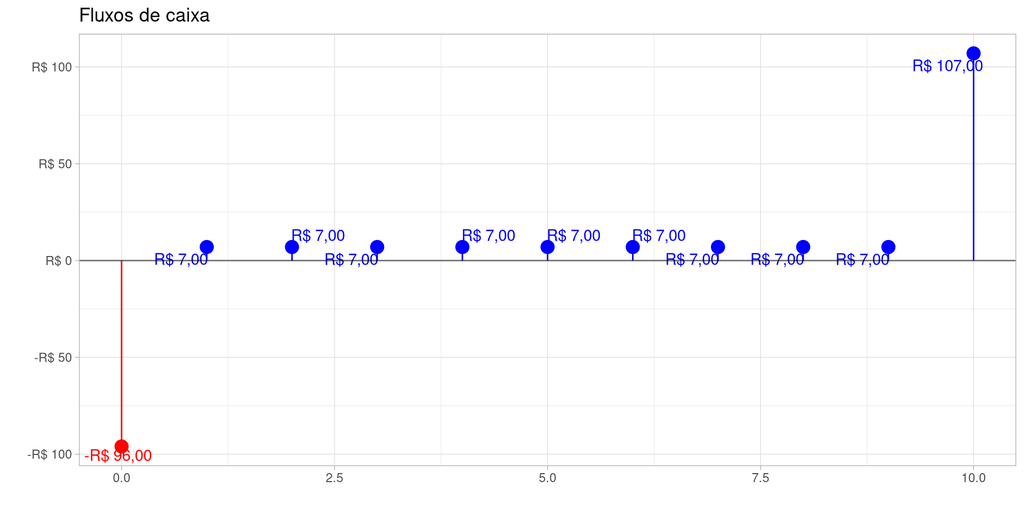

TIR do título (YTM) = 7,59%

Custo do capital = 7,59%

# Custo do capital da empresa (WACC)

## Conceito

> WACC (*Weighted Average Cost of Capital*): Média ponderada dos custos de capital próprio e capital de terceiros da empresa
- Pesos dados pela participação no valor total da empresa:

$$PESO_{CP} = \frac{TotalCP}{TotalCP + TotalCT}$$
$$PESO_{CT} = \frac{TotalCT}{TotalCP + TotalCT}$$

Onde:

$TotalCP$ - Total de capital próprio na empresa

$TotalCT$ - Total de capital de terceiros na empresa

## Efeito do imposto sobre Capital de terceiros

> O valor pago pelo capital de terceiros é abatido do imposto.

$$R_{CT} ^{efetiva} = R_{CT} ^{nominal}(1-T_C)$$
Onde:

$R_{CT} ^{efetiva}$ - Custo efetivo do capital de terceiros

$R_{CT} ^{nominal}$ - Custo nominal do capital de terceiros (TIR da dívida)

$T_C$ - Alíquota de imposto sobre lucro tributável

## Exemplo Efeito dos Impostos

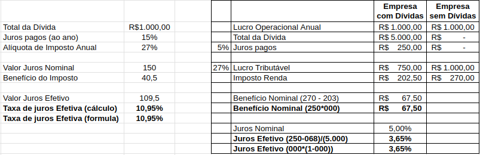

Exemplo do efeito do imposto – [Link](https://docs.google.com/spreadsheets/d/1NxzxCR6cSV9g0j-rxyiDMsVge4bbyOlwresr0Kf6FEI/edit?usp=sharing)

## Fórmula WACC

$$WACC = PESO_{CP}*R_{CP} + PESO_{CT}*R_{CT}*(1-T_C)$$

Onde:

$PESO_{CP}$ - % de capital próprio na empresa

$PESO_{CT}$ - % de capital de terceiros na empresa

$R_{CP}$ - Custo do capital próprio da empresa

$R_{CT}$ - Custo nominal do capital de terceiros da empresa

$T_C$ - Alíquota de imposto sobre lucro tributável

## Cálculo do WACC para Engie

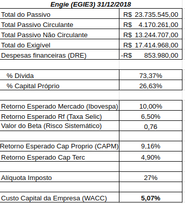

WACC da Engie (EGIE3) – [Link](https://docs.google.com/spreadsheets/d/1NxzxCR6cSV9g0j-rxyiDMsVge4bbyOlwresr0Kf6FEI/edit?usp=sharing)

# Problemas com o WACC

## Alguns problemas com o WACC

- WACC só é aplicado se o projeto possuir risco semelhante ao da empresa
- Assume-se que os betas dos projetos são iguais ao beta da empresa
- Possibilidade de aceitar/rejeitar projetos de forma equivocada caso o beta do projeto não for igual ao beta da empresa

## WACC para empresas não negociadas em Bolsa

- Abordagem Objetiva (ou aposta simples):
  - Verificar custos de capital de empresas com riscos semelhantes ao projeto
    - Exemplo: telefonia, setor financeiro
- Abordagem Subjetiva
  - Elencar riscos de forma subjetiva e criar fatores de ajuste sobre o WACC da empresa

## Exemplo Abordagem Subjetiva

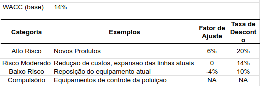

## Referências

Gordon, Myron J, and Eli Shapiro. 1956. “Capital Equipment Analysis: The Required Rate of Profit.” *Management Science* 3 (1): 102–10.

Ross, Stephen, Randolph Westerfield, Bradford Jordan, et al. 2022. *Fundamentos de Administração Financeira*. Bookman Editora.